# Bayesian GLM Part6

- stan_acf (auto-correlation function): plots the auto-correlation between successive MCMC sample lags for each parameter and each chain

```
'pars' not specified. Showing first 10 parameters by default.
```

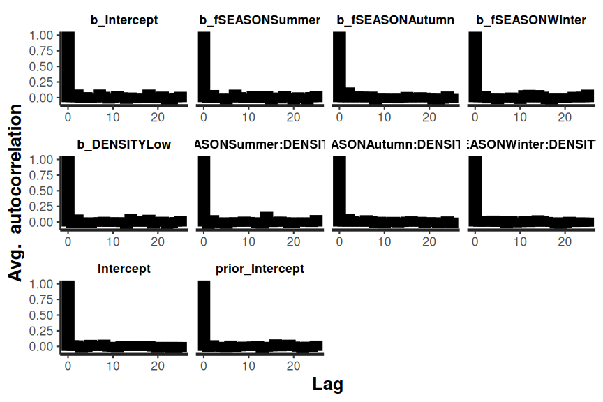

```r
quinn_brmP$fit |> stan_ac()
```

There is no evidence of auto-correlation in the MCMC samples

- stan_rhat: Rhat is a **scale reduction factor** measure of convergence between the chains. The closer the values are to 1, the more the chains have converged. Values greater than 1.05 indicate a lack of convergence. There will be an Rhat value for each parameter estimated.

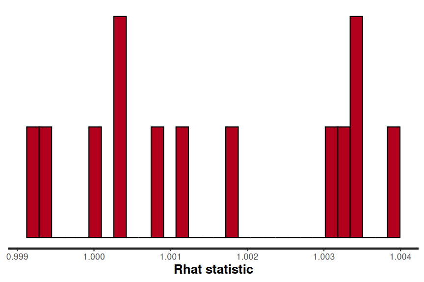

```r
quinn_brmP$fit |> stan_rhat()
```

All Rhat values are below 1.05, suggesting the chains have converged.

- stan_ess (number of effective samples): the ratio of the number of effective samples (those not rejected by the sampler) to the number of samples provides an indication of the effectiveness (and efficiency) of the MCMC sampler. Ratios that are less than 0.5 for a parameter suggest that the sampler spent considerable time in difficult areas of the sampling domain and rejected more than half of the samples (replacing them with the previous effective sample).

  If the ratios are low, tightening the priors may help.

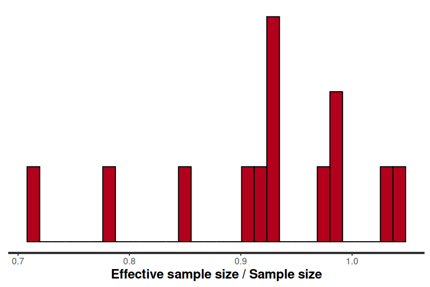

```r
quinn_brmP$fit |> stan_ess()
```

Ratios all very high.

```
'pars' not specified. Showing first 10 parameters by default.
```

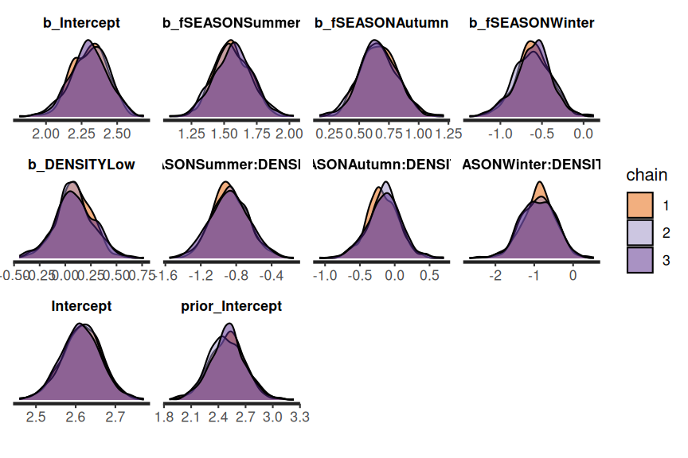

```r
quinn_brmP$fit |> stan_dens(separate_chains = TRUE)
```

# 7 Model validation

**rstanarm**

**pp check**

Post predictive checks provide additional diagnostics about the fit of the model. Specifically, they provide a comparison between predictions drawn from the model and the observed data used to train the model.

```r
available_ppc()
```

```
bayesplot PPC module:
  ppc_bars
  ppc_bars_grouped
  ppc_boxplot
  ppc_dens
  ppc_dens_overlay
  ppc_dens_overlay_grouped
  ppc_dots
  ppc_ecdf_overlay
  ppc_ecdf_overlay_grouped
  ppc_error_binned
  ppc_error_hist
  ppc_error_hist_grouped
  ppc_error_scatter
  ppc_error_scatter_avg
  ppc_error_scatter_avg_grouped
  ppc_error_scatter_avg_vs_x
  ppc_freqpoly
  ppc_freqpoly_grouped
  ppc_hist
  ppc_intervals
  ppc_intervals_grouped
  ppc_km_overlay
  ppc_km_overlay_grouped
  ppc_loo_intervals
  ppc_loo_pit_ecdf
  ppc_loo_pit_overlay
  ppc_loo_pit_qq
  ppc_loo_ribbon
  ppc_pit_ecdf
  ppc_pit_ecdf_grouped
  ppc_ribbon
  ppc_ribbon_grouped
  ppc_rootogram
  ppc_scatter
  ppc_scatter_avg
  ppc_scatter_avg_grouped
  ppc_stat
  ppc_stat_2d
  ppc_stat_freqpoly
  ppc_stat_freqpoly_grouped
  ppc_stat_grouped
  ppc_violin_grouped
```

- dens_overlay: plots the density distribution of the observed data (black line) overlayed on top of 50 density distributions generated from draws from the model (light blue). Ideally, the 50 realisations should be roughly consistent with the observed data.

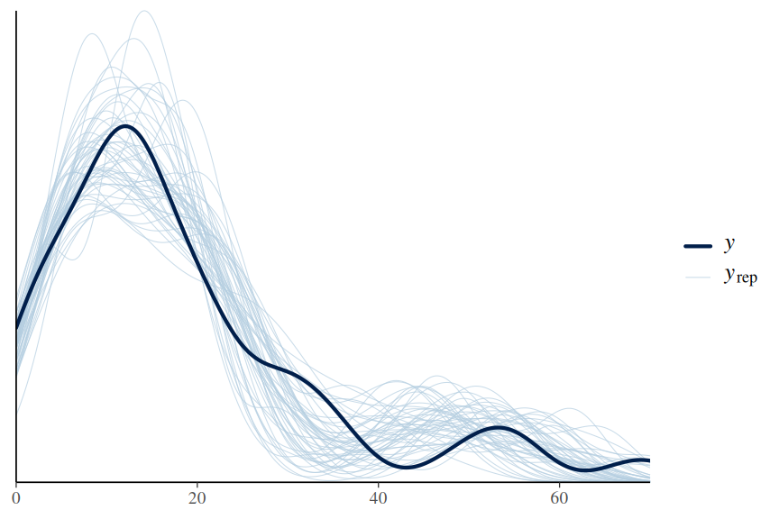

```r
pp_check(quinn_rstanarm3, plotfun = "dens_overlay")
```

The model draws are broadly similar to the observed data.

```r
# pp_check(quinn_rstanarm3, plotfun='error_scatter_avg')
```

- error_scatter_avg_vs_x: this is similar to a regular residual plot and as such should be interpreted as such.

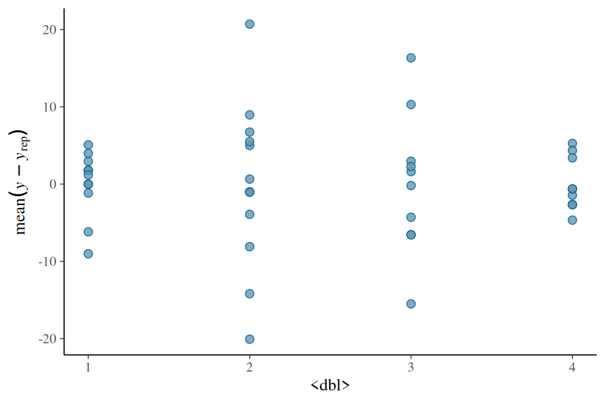

```r
pp_check(quinn_rstanarm3, x = as.numeric(quinn$fSEASON), plotfun = "error_scatter_avg_vs_x")
```

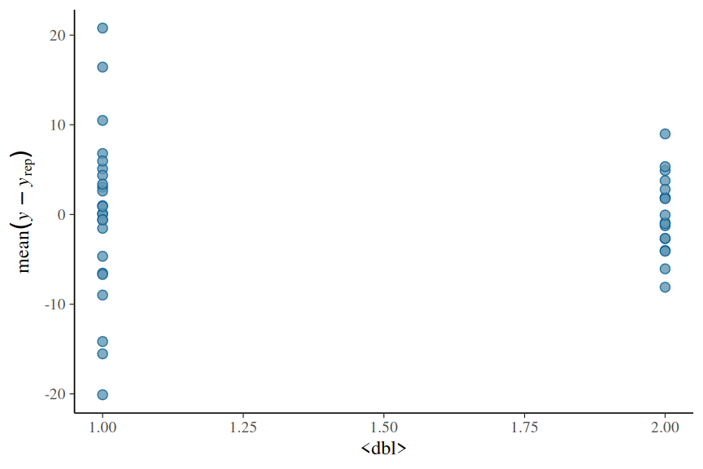

```r
pp_check(quinn_rstanarm3, x = as.numeric(quinn$DENSITY), plotfun = "error_scatter_avg_vs_x")
```

- intervals: plots the observed data overlayed on top of posterior predictions associated with each level of the predictor. Ideally, the observed data should all fall within the predictive intervals.

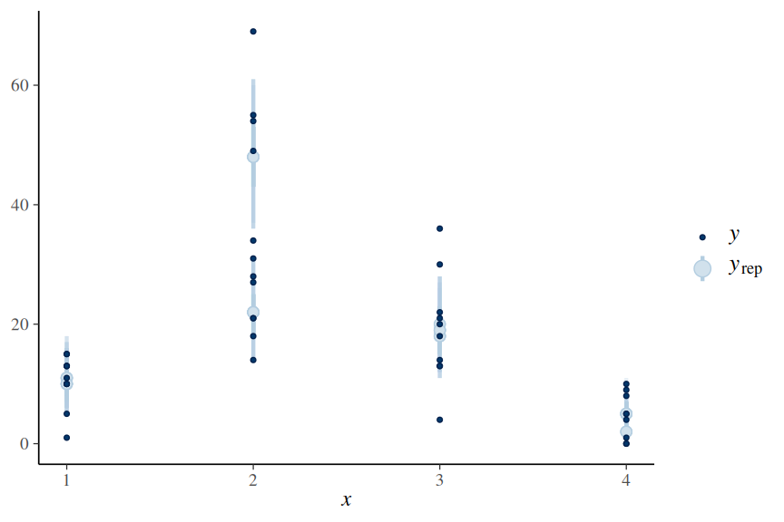

```r
pp_check(quinn_rstanarm3, x = as.numeric(quinn$fSEASON), plotfun = "intervals")
```

The modelled predictions seem to do a reasonable job of representing the observations.

The `shinystan` package allows the full suite of MCMC diagnostics and posterior predictive checks to be accessed via a web interface.

```r
# library(shinystan)
# launch_shinystan(quinn_rstanarm3)
```

**DHARMa residuals**

DHARMa residuals provide very useful diagnostics. Unfortunately, we cannot directly use the `simulateResiduals()` function to generate the simulated residuals. However, if we are willing to calculate some of the components yourself, we can still obtain the simulated residuals from the fitted stan model.

We need to supply:

- simulated (predicted) responses associated with each observation.
- observed values
- fitted (predicted) responses (averaged) associated with each observation

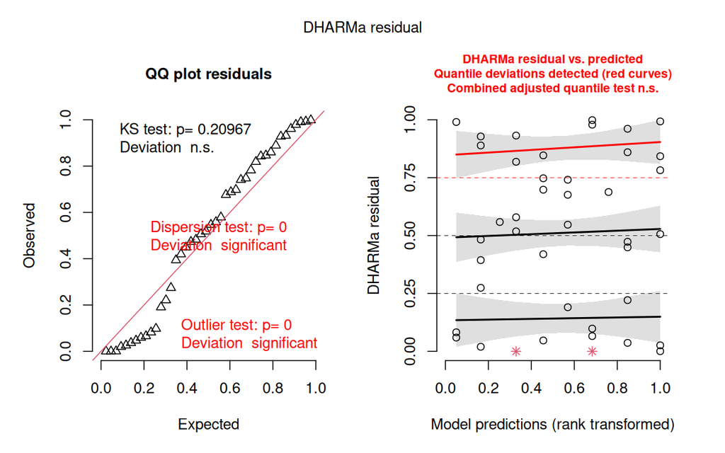

```r
preds <- posterior_predict(quinn_rstanarm3, nsamples = 250, summary = FALSE)
quinn_resids <- createDHARMa(
  simulatedResponse = t(preds),
  observedResponse = quinn$RECRUITS,
  fittedPredictedResponse = apply(preds, 2, median),
  integerResponse = TRUE
)
plot(quinn_resids)
```

**Conclusions:**

- the simulated residuals suggest there might be an issue of dispersion.
- it might be worth exploring either zero-inflation, a negative binomial model, or including a observation-level random effect.

**brms**

**pp check**

Post predictive checks provide additional diagnostics about the fit of the model. Specifically, they provide a comparison between predictions drawn from the model and the observed data used to train the model.

```r
available_ppc()
```

```
bayesplot PPC module:
  ppc_bars
  ppc_bars_grouped
  ppc_boxplot
  ppc_dens
  ppc_dens_overlay
  ppc_dens_overlay_grouped
  ppc_dots
  ppc_ecdf_overlay
  ppc_ecdf_overlay_grouped
  ppc_error_binned
  ppc_error_hist
  ppc_error_hist_grouped
  ppc_error_scatter
  ppc_error_scatter_avg
  ppc_error_scatter_avg_grouped
  ppc_error_scatter_avg_vs_x
  ppc_freqpoly
  ppc_freqpoly_grouped
  ppc_hist
  ppc_intervals
  ppc_intervals_grouped
  ppc_km_overlay
  ppc_km_overlay_grouped
  ppc_loo_intervals
  ppc_loo_pit_ecdf
  ppc_loo_pit_overlay
  ppc_loo_pit_qq
  ppc_loo_ribbon
  ppc_pit_ecdf
  ppc_pit_ecdf_grouped
  ppc_ribbon
  ppc_ribbon_grouped
  ppc_rootogram
  ppc_scatter
  ppc_scatter_avg
  ppc_scatter_avg_grouped
  ppc_stat
  ppc_stat_2d
  ppc_stat_freqpoly
  ppc_stat_freqpoly_grouped
  ppc_stat_grouped
  ppc_violin_grouped
```

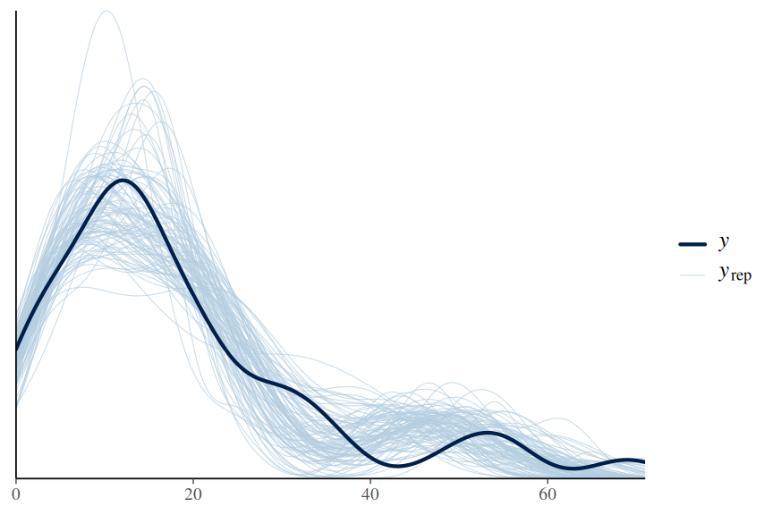

```r
quinn_brmP |> pp_check(type = "dens_overlay", ndraws = 100)
```

The model draws appear to represent the shape of the observed data reasonably well

```r
# quinn_brmP |> pp_check(type = 'error_scatter_avg')
```

- intervals: plots the observed data overlayed on top of posterior predictions associated with each level of the predictor. Ideally, the observed data should all fall within the predictive intervals.

```
Using all posterior draws for ppc type 'intervals' by default.
```

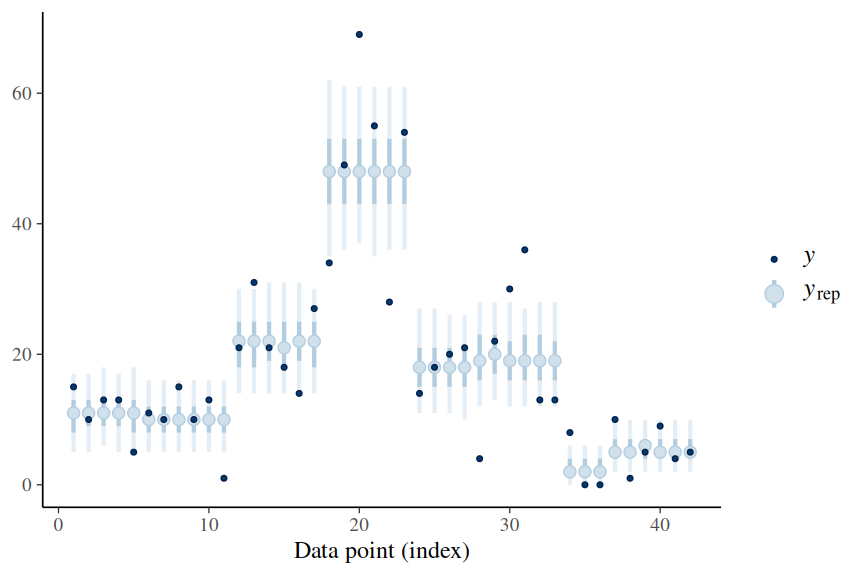

```r
quinn_brmP |> pp_check(type = "intervals")
```

```r
## quinn_brmP |> pp_check(group='DENSITY', type='intervals')
```

Whilst the modelled predictions do a reasonable job of representing the observed data, the observed data do appear to be more varied than the model is representing.

The `shinystan` package allows the full suite of MCMC diagnostics and posterior predictive checks to be accessed via a web interface.

```r
# library(shinystan)
# launch_shinystan(quinn_brmP)
```

**DHARMa residuals**

DHARMa residuals provide very useful diagnostics. Unfortunately, we cannot directly use the `simulateResiduals()` function to generate the simulated residuals. However, if we are willing to calculate some of the components yourself, we can still obtain the simulated residuals from the fitted stan model.

We need to supply:

- simulated (predicted) responses associated with each observation.
- observed values
- fitted (predicted) responses (averaged) associated with each observation

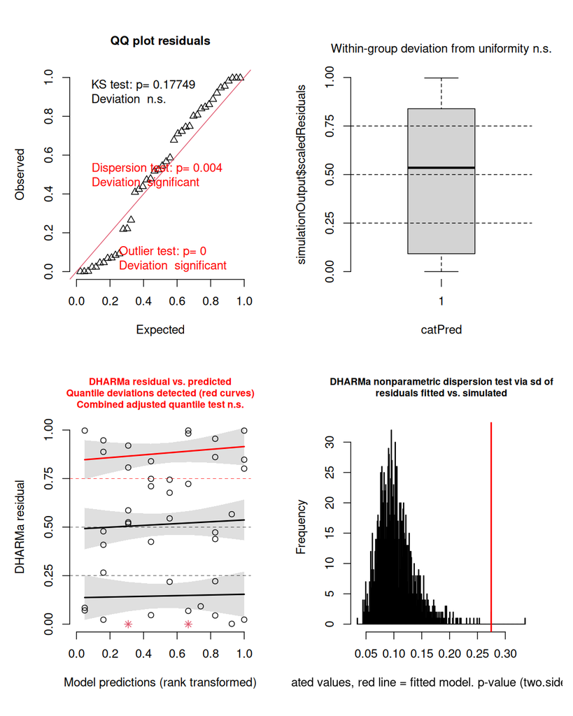

```r
quinn_resids <- make_brms_dharma_res(quinn_brmP, integerResponse = TRUE)
wrap_elements(~ testUniformity(quinn_resids)) +
  wrap_elements(~ plotResiduals(quinn_resids, form = factor(rep(1, nrow(quinn))))) +
  wrap_elements(~ plotResiduals(quinn_resids, quantreg = TRUE)) +
  wrap_elements(~ testDispersion(quinn_resids))
```

**Conclusions:**

- the simulated residuals do suggest that there might be a dispersion issue
- it might be worth exploring either zero-inflation, a negative binomial model, or including a observation-level random effect.

And the old (and now incorrect) way…

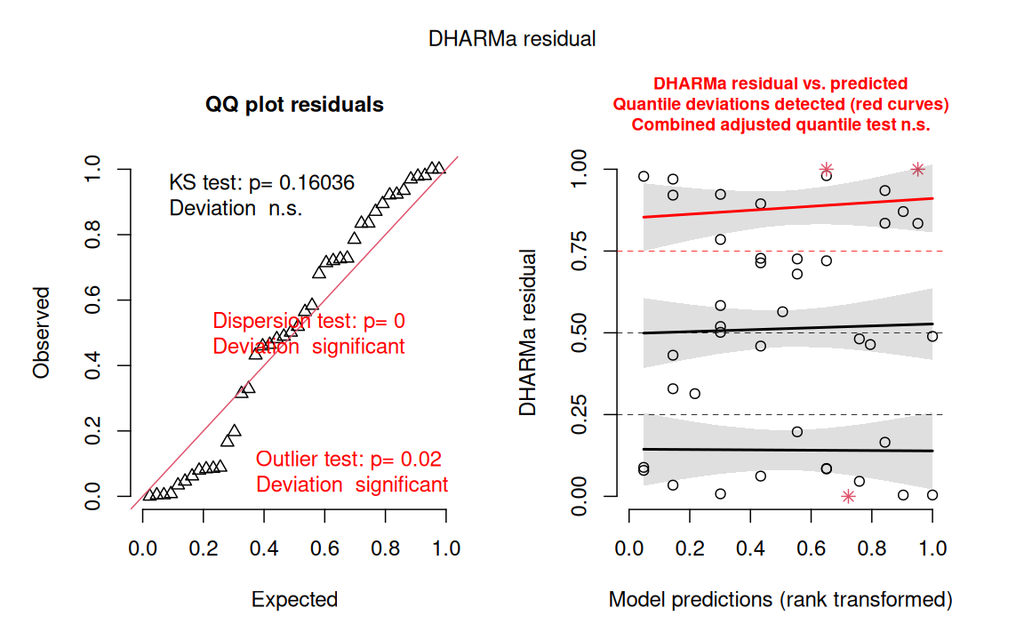

```r
preds <- quinn_brmP |> posterior_predict(nsamples = 250, summary = FALSE)
quinn_resids <- createDHARMa(
  simulatedResponse = t(preds),
  observedResponse = quinn$RECRUITS,
  fittedPredictedResponse = apply(preds, 2, median),
  integerResponse = TRUE
)
quinn_resids |> plot()
```

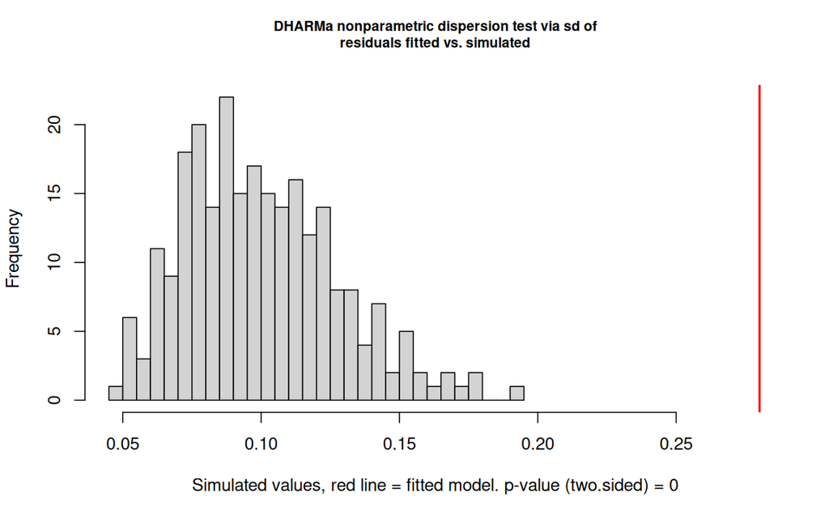

```
    DHARMa nonparametric dispersion test via sd of residuals fitted vs.
    simulated

data:  simulationOutput
dispersion = 2.8028, p-value < 2.2e-16
alternative hypothesis: two.sided
```

```r
quinn_resids |> testDispersion()
```

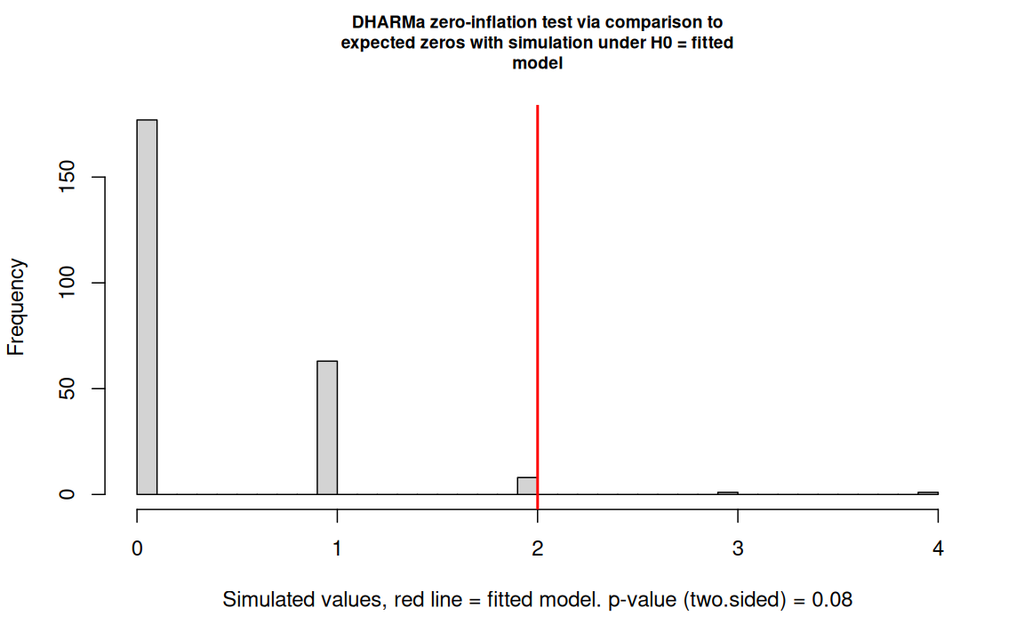

```
    DHARMa zero-inflation test via comparison to expected zeros with
    simulation under H0 = fitted model

data:  simulationOutput
ratioObsSim = 5.814, p-value = 0.08
alternative hypothesis: two.sided
```

```r
quinn_resids |> testZeroInflation()
```

Clearly this is overdispersed…

# 8 Explore negative binomial model

**rstanarm**

**Fit model**

```r
quinn_rstanarmNB <- stan_glm(RECRUITS ~ fSEASON * DENSITY,
  data = quinn,
  family = neg_binomial_2(link = "log"),
  prior_intercept = normal(2.3, 2, autoscale = FALSE),
  prior = normal(0, 10, autoscale = FALSE),
  prior_aux = rstanarm::exponential(rate = 1, autoscale = FALSE),
  prior_PD = FALSE,
  refresh = 0,
  chains = 3, iter = 5000, thin = 5, warmup = 2000
)
```

**Explore posteriors vs priors**

```
Drawing from prior...
```

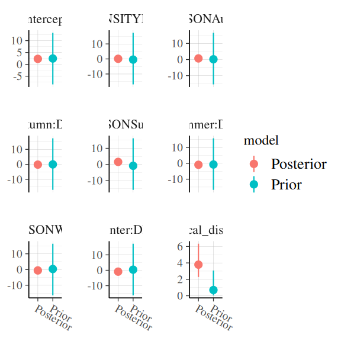

```r
posterior_vs_prior(quinn_rstanarmNB,
  color_by = "vs", group_by = TRUE,
  facet_args = list(scales = "free_y")
)
```

**ggpredict**

```
Data points may overlap. Use the `jitter` argument to add some amount of
  random variation to the location of data points and avoid overplotting.
```

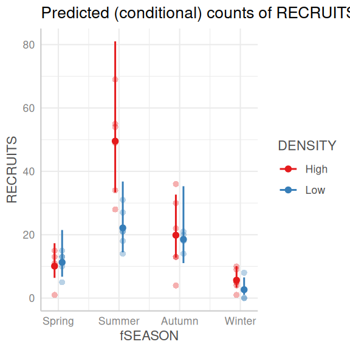

```r
quinn_rstanarmNB |>
  ggpredict(~ fSEASON + DENSITY) |>
  plot(show_data = TRUE)
```

**ggemmeans**

```
Data points may overlap. Use the `jitter` argument to add some amount of
  random variation to the location of data points and avoid overplotting.
```

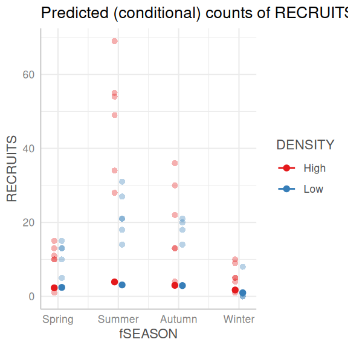

```r
quinn_rstanarmNB |>
  ggemmeans(~ fSEASON + DENSITY, back.transform = TRUE) |>
  plot(show_data = TRUE)
```

There seems to be a bug here. The expected values should be being back transformed to the response scale, however, they are clearly not. Notice that the expected values (and associated CI) are low and tiny respectively).

**MCMC diagnostics**

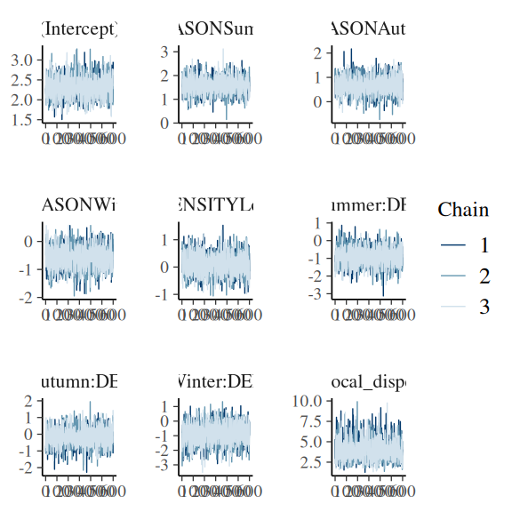

```r
quinn_rstanarmNB |> plot("mcmc_trace")
```

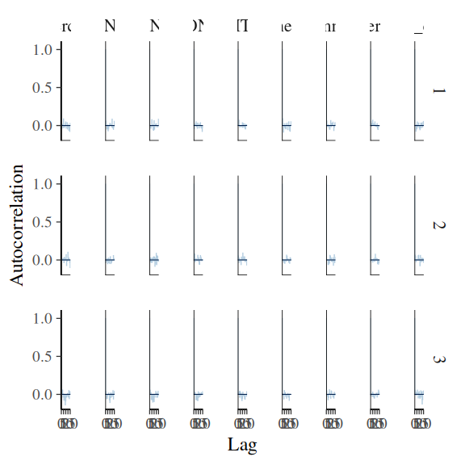

```r
quinn_rstanarmNB |> plot("mcmc_acf_bar")
```

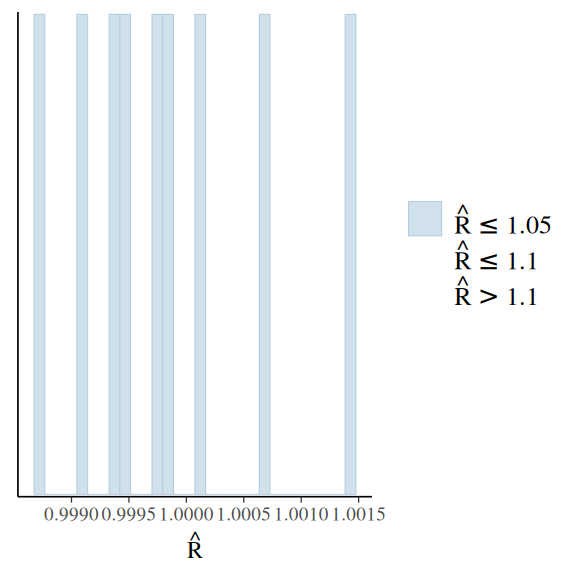

```r
quinn_rstanarmNB |> plot("mcmc_rhat_hist")
```

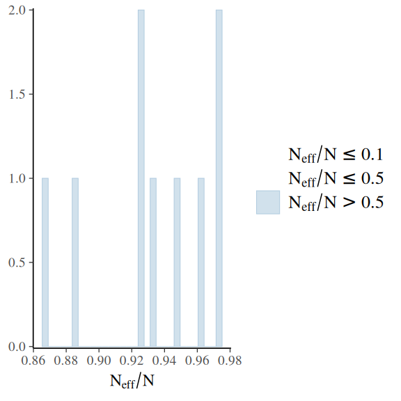

```r
quinn_rstanarmNB |> plot("mcmc_neff_hist")
```

**DHARMa residuals**

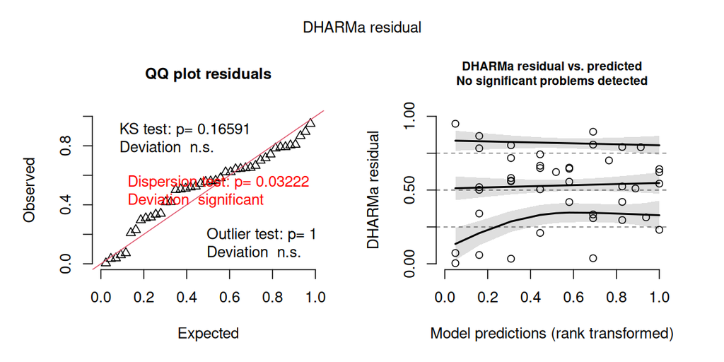

```r
preds <- posterior_predict(quinn_rstanarmNB, nsamples = 250, summary = FALSE)
quinn_resids <- createDHARMa(
  simulatedResponse = t(preds),
  observedResponse = quinn$RECRUITS,
  fittedPredictedResponse = apply(preds, 2, median),
  integerResponse = TRUE
)
plot(quinn_resids)
```

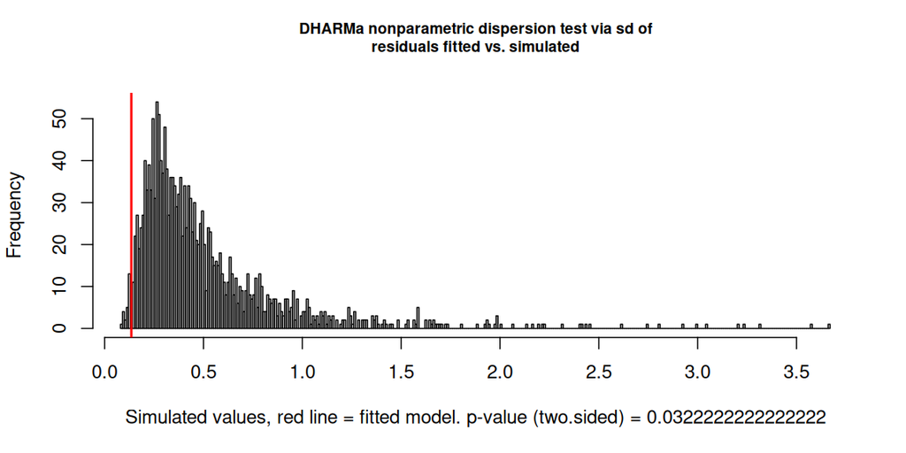

```
    DHARMa nonparametric dispersion test via sd of residuals fitted vs.
    simulated

data:  simulationOutput
dispersion = 0.26436, p-value = 0.03222
alternative hypothesis: two.sided
```

```r
quinn_resids |> testDispersion()
```

Now possibly under-dispersed..

**Model comparison**

```r
(loo.P <- loo(quinn_rstanarmP))
```

```
Computed from 1800 by 42 log-likelihood matrix.

         Estimate   SE
elpd_loo   -170.4 15.6
p_loo        23.7  5.5
looic       340.8 31.1
------
MCSE of elpd_loo is NA.
MCSE and ESS estimates assume MCMC draws (r_eff in [0.8, 1.1]).

Pareto k diagnostic values:
                          Count Pct.    Min. ESS
(-Inf, 0.69]   (good)     39    92.9%   201
   (0.69, 1]   (bad)       2     4.8%   <NA>
    (1, Inf)   (very bad)  1     2.4%   <NA>
See help('pareto-k-diagnostic') for details.
```

```r
(loo.NB <- loo(quinn_rstanarmNB))
```

```
Computed from 1800 by 42 log-likelihood matrix.

         Estimate   SE
elpd_loo   -150.3  5.8
p_loo         9.1  3.2
looic       300.6 11.6
------
MCSE of elpd_loo is NA.
MCSE and ESS estimates assume MCMC draws (r_eff in [0.8, 1.1]).

Pareto k diagnostic values:
                          Count Pct.    Min. ESS
(-Inf, 0.69]   (good)     41    97.6%   635
   (0.69, 1]   (bad)       0     0.0%   <NA>
    (1, Inf)   (very bad)  1     2.4%   <NA>
See help('pareto-k-diagnostic') for details.
```

```r
loo_compare(loo.P, loo.NB)
```

```
                 elpd_diff se_diff
quinn_rstanarmNB   0.0       0.0
quinn_rstanarmP  -20.1      11.9
```

**brms**

**Fit model**

```r
quinn_form <- bf(RECRUITS ~ fSEASON * DENSITY, family = negbinomial(link = "log"))
get_prior(quinn_form, data = quinn)
```

```
                  prior     class                     coef group resp dpar
                 (flat)         b
                 (flat)         b               DENSITYLow
                 (flat)         b            fSEASONAutumn
                 (flat)         b fSEASONAutumn:DENSITYLow
                 (flat)         b            fSEASONSummer
                 (flat)         b fSEASONSummer:DENSITYLow
                 (flat)         b            fSEASONWinter
                 (flat)         b fSEASONWinter:DENSITYLow
 student_t(3, 2.6, 2.5) Intercept
    inv_gamma(0.4, 0.3)     shape
 nlpar lb ub       source
                  default
             (vectorized)
             (vectorized)
             (vectorized)
             (vectorized)
             (vectorized)
             (vectorized)
             (vectorized)
                  default
        0         default
```

```r
priors <- prior(normal(2.5, 0.2), class = "Intercept") +
  prior(normal(0, 2.5), class = "b") +
  prior(gamma(0.01, 0.01), class = "shape")
quinn_brmsNB <- brm(quinn_form,
  data = quinn,
  prior = priors,
  refresh = 0,
  chains = 3,
  iter = 5000,
  thin = 5,
  warmup = 2500,
  backend = "rstan"
)
```

**DHARMa residuals**

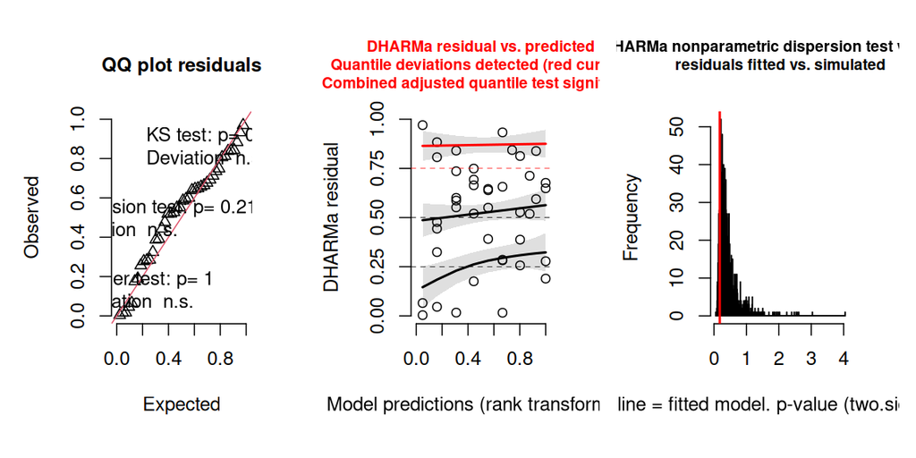

```r
quinn_resids <- make_brms_dharma_res(quinn_brmsNB, integerResponse = TRUE)
wrap_elements(~ testUniformity(quinn_resids)) +
  ## wrap_elements(~plotResiduals(quinn_resids, form = factor(rep(1, nrow(quinn))))) +
  wrap_elements(~ plotResiduals(quinn_resids, quantreg = TRUE)) +
  wrap_elements(~ testDispersion(quinn_resids))
```

# 9 Partial effects plots

**rstanarm**

**ggpredict**

```
Data points may overlap. Use the `jitter` argument to add some amount of
  random variation to the location of data points and avoid overplotting.
```

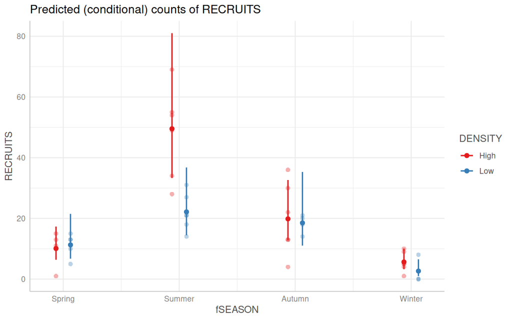

```r
quinn_rstanarmNB |>
  ggpredict(~ fSEASON + DENSITY) |>
  plot(show_data = TRUE)
```

**ggemmeans**

```
Data points may overlap. Use the `jitter` argument to add some amount of
  random variation to the location of data points and avoid overplotting.
```

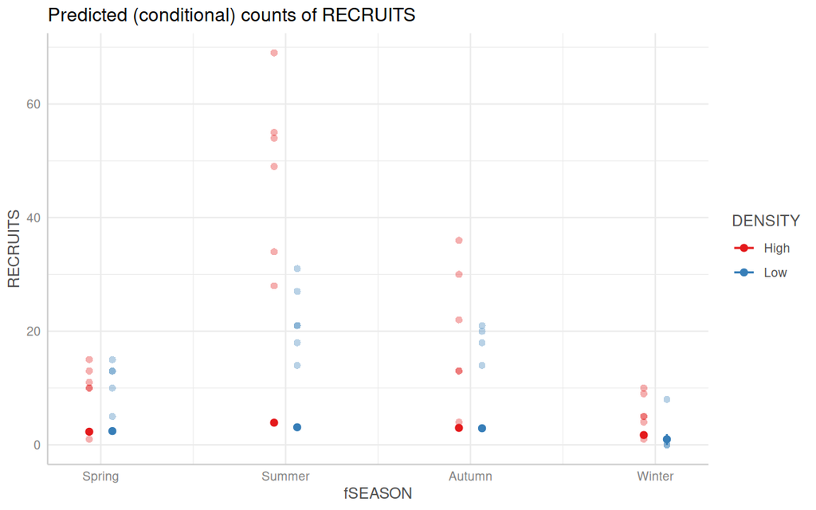

```r
quinn_rstanarmNB |>
  ggemmeans(~ fSEASON | DENSITY, type = "fixed", back.transform = TRUE) |>
  plot(show_data = TRUE)
```

**fitted_draws**

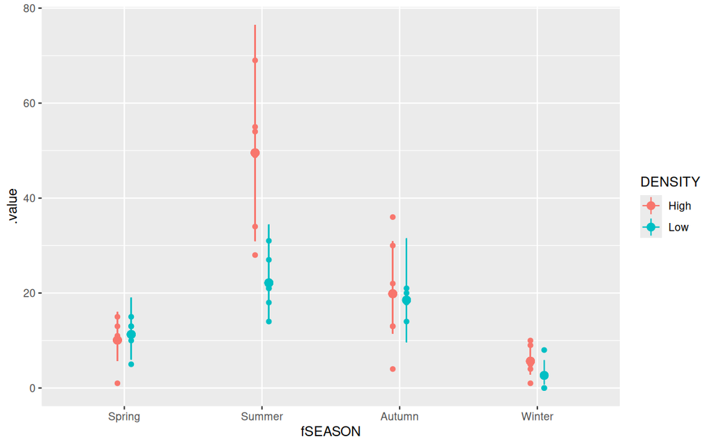

```r
quinn_rstanarmNB |>
  fitted_draws(newdata = quinn) |>
  median_hdci() |>
  ggplot(aes(x = fSEASON, colour = DENSITY, y = .value)) +
  geom_pointrange(aes(ymin = .lower, ymax = .upper), position = position_dodge(width = 0.2)) +
  geom_line(position = position_dodge(width = 0.2)) +
  geom_point(data = quinn, aes(y = RECRUITS, x = fSEASON, colour = DENSITY), position = position_dodge(width = 0.2))
```

**brms**

**conditional_effects**

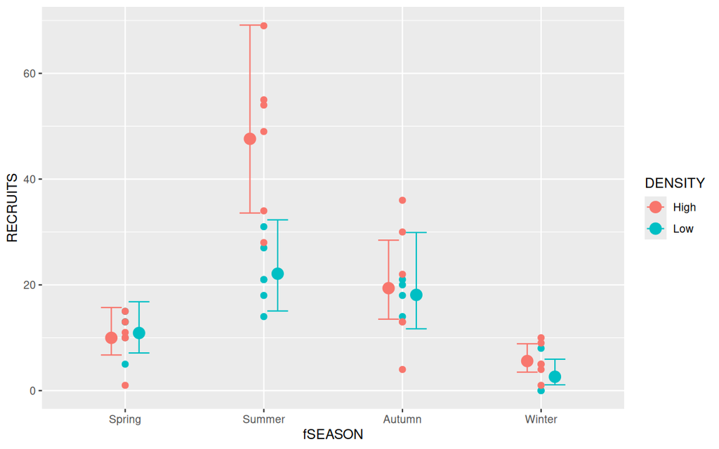

```r
quinn_brmsNB |>
  conditional_effects("fSEASON:DENSITY") |>
  plot(points = TRUE)
```

**ggpredict**

```
Data points may overlap. Use the `jitter` argument to add some amount of
  random variation to the location of data points and avoid overplotting.
```

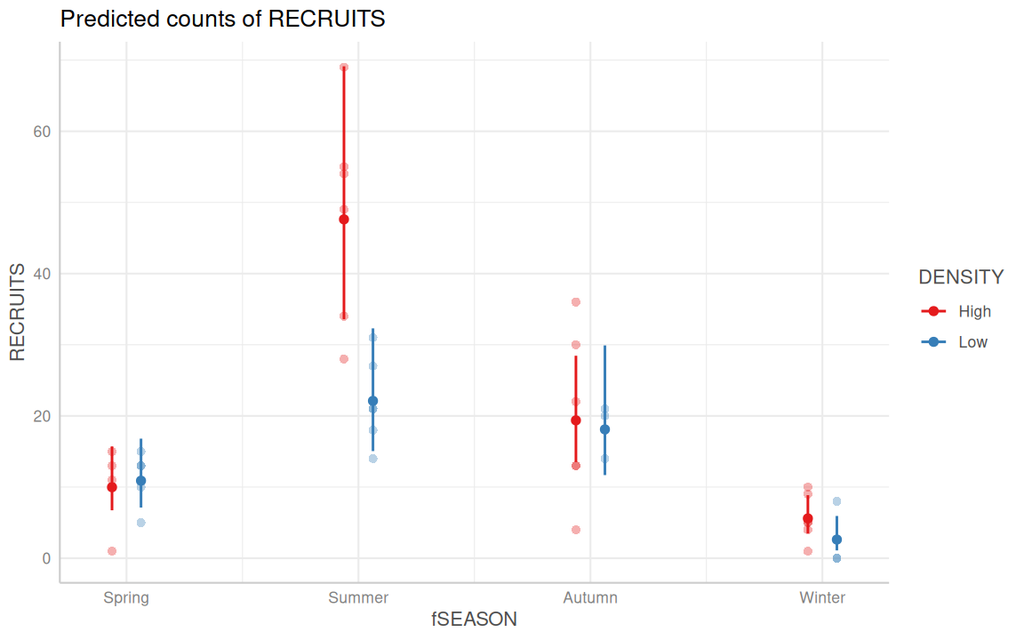

```r
quinn_brmsNB |>
  ggpredict(~ fSEASON + DENSITY) |>
  plot(show_data = TRUE)
```

**ggemmeans**

```
Data points may overlap. Use the `jitter` argument to add some amount of
  random variation to the location of data points and avoid overplotting.
```

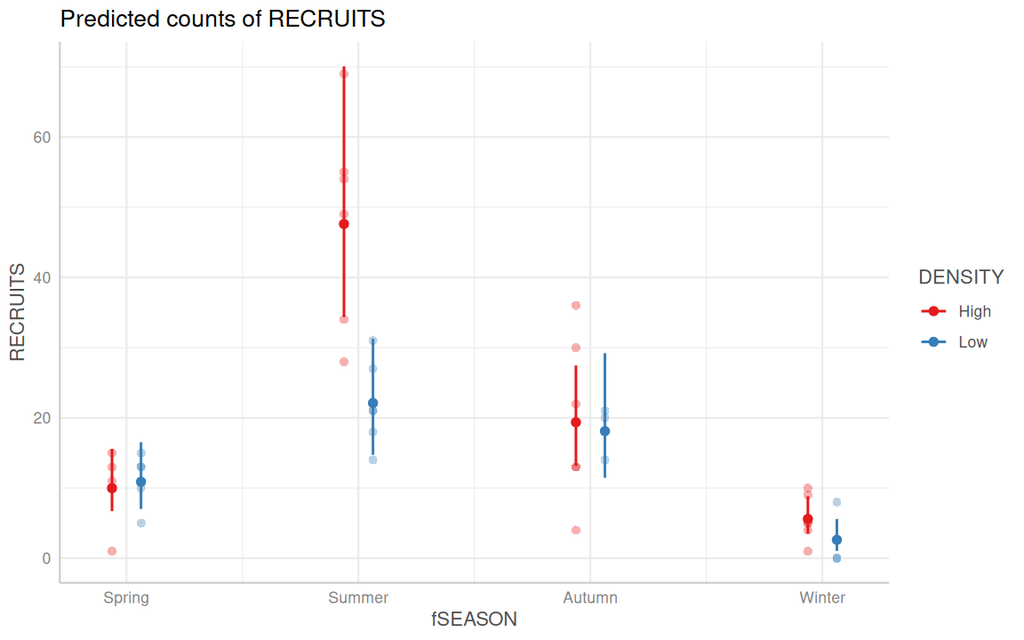

```r
quinn_brmsNB |>
  ggemmeans(~ fSEASON | DENSITY) |>
  plot(show_data = TRUE)
```

**fitted_draws**

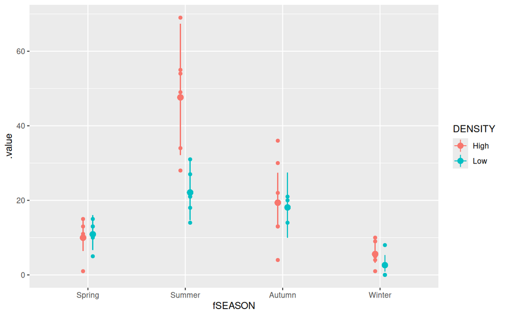

```r
quinn_brmsNB |>
  fitted_draws(newdata = quinn) |>
  median_hdci() |>
  ggplot(aes(x = fSEASON, colour = DENSITY, y = .value)) +
  geom_pointrange(aes(ymin = .lower, ymax = .upper), position = position_dodge(width = 0.2)) +
  geom_line(position = position_dodge(width = 0.2)) +
  geom_point(data = quinn, aes(y = RECRUITS, x = fSEASON, colour = DENSITY), position = position_dodge(width = 0.2))
```

# 10 Model investigation

**rstanarm**

**summary**

The `summary()` method generates simple summaries (mean, standard deviation as well as 10, 50 and 90 percentiles).

```r
quinn_rstanarmNB |> summary()
```

```
Model Info:
 function:     stan_glm
 family:       neg_binomial_2 [log]
 formula:      RECRUITS ~ fSEASON * DENSITY
 algorithm:    sampling
 sample:       1800 (posterior sample size)
 priors:       see help('prior_summary')
 observations: 42
 predictors:   8

Estimates:
                           mean   sd   10%   50%   90%
(Intercept)               2.3    0.3  2.0   2.3   2.6
fSEASONSummer             1.6    0.3  1.2   1.6   2.0
fSEASONAutumn             0.7    0.3  0.2   0.7   1.1
fSEASONWinter            -0.6    0.4 -1.1  -0.6  -0.1
DENSITYLow                0.1    0.4 -0.4   0.1   0.6
fSEASONSummer:DENSITYLow -0.9    0.5 -1.6  -0.9  -0.3
fSEASONAutumn:DENSITYLow -0.2    0.5 -0.9  -0.2   0.5
fSEASONWinter:DENSITYLow -0.9    0.7 -1.7  -0.9   0.0
reciprocal_dispersion     4.0    1.3  2.6   3.8   5.6

Fit Diagnostics:
           mean   sd   10%   50%   90%
mean_PPD 19.4    3.1 15.8  19.0  23.4

The mean_ppd is the sample average posterior predictive distribution of the outcome variable (for details see help('summary.stanreg')).

MCMC diagnostics
                         mcse Rhat n_eff
(Intercept)              0.0  1.0  1561
fSEASONSummer            0.0  1.0  1731
fSEASONAutumn            0.0  1.0  1752
fSEASONWinter            0.0  1.0  1706
DENSITYLow               0.0  1.0  1592
fSEASONSummer:DENSITYLow 0.0  1.0  1682
fSEASONAutumn:DENSITYLow 0.0  1.0  1667
fSEASONWinter:DENSITYLow 0.0  1.0  1752
reciprocal_dispersion    0.0  1.0  1669
mean_PPD                 0.1  1.0  1525
log-posterior            0.1  1.0  1560

For each parameter, mcse is Monte Carlo standard error, n_eff is a crude measure of effective sample size, and Rhat is the potential scale reduction factor on split chains (at convergence Rhat=1).
```

**Conclusions:**

**tidyMCMC**

```r
tidyMCMC(quinn_rstanarmNB$stanfit, estimate.method = "median", conf.int = TRUE, conf.method = "HPDinterval", rhat = TRUE, ess = TRUE)
```

```
# A tibble: 11 × 7
   term                     estimate std.error   conf.low conf.high  rhat   ess
   <chr>                       <dbl>     <dbl>      <dbl>     <dbl> <dbl> <int>
 1 (Intercept)                 2.32      0.254    1.80        2.80  1.00   1561
 2 fSEASONSummer               1.60      0.337    0.930       2.24  0.999  1731
 3 fSEASONAutumn               0.679     0.348    0.00813     1.36  1.00   1752
 4 fSEASONWinter              -0.585     0.376   -1.33        0.152 0.999  1706
 5 DENSITYLow                  0.119     0.377   -0.614       0.861 0.999  1592
 6 fSEASONSummer:DENSITYLow   -0.921     0.505   -1.84        0.112 1.000  1682
 7 fSEASONAutumn:DENSITYLow   -0.182     0.540   -1.20        0.940 1.000  1667
 8 fSEASONWinter:DENSITYLow   -0.884     0.690   -2.29        0.423 0.999  1752
 9 reciprocal_dispersion       3.97      1.25     1.82        6.50  1.00   1669
10 mean_PPD                   19.4       3.14    14.1        26.0   1.000  1525
11 log-posterior            -155.        2.45  -160.       -151.    0.999  1560
```

**Conclusions:**

See above

**summarise_draws (posterior)**

```r
quinn_rstanarmNB$stanfit |>
  summarise_draws(
    median,
    HDInterval::hdi,
    rhat, length, ess_bulk, ess_tail
  )
```

```
# A tibble: 11 × 8
   variable              median    lower    upper  rhat length ess_bulk ess_tail
   <chr>                  <dbl>    <dbl>    <dbl> <dbl>  <dbl>    <dbl>    <dbl>
 1 (Intercept)            2.31   1.80e+0    2.80  1.00    1800    1570.    1747.
 2 fSEASONSummer          1.60   9.30e-1    2.24  0.999   1800    1737.    1749.
 3 fSEASONAutumn          0.682  8.13e-3    1.36  1.00    1800    1757.    1707.
 4 fSEASONWinter         -0.582 -1.33e+0    0.152 1.00    1800    1706.    1790.
 5 DENSITYLow             0.112 -6.14e-1    0.861 0.999   1800    1605.    1655.
 6 fSEASONSummer:DENS…   -0.931 -1.84e+0    0.112 1.000   1800    1679.    1744.
 7 fSEASONAutumn:DENS…   -0.181 -1.20e+0    0.940 1.00    1800    1669.    1744.
 8 fSEASONWinter:DENS…   -0.891 -2.29e+0    0.423 0.999   1800    1744.    1654.
 9 reciprocal_dispers…    3.79   1.82e+0    6.50  1.00    1800    1649.    1850.
10 mean_PPD              19.0    1.41e+1   26.0   0.999   1800    1525.    1647.
11 log-posterior       -155.    -1.60e+2 -151.    1.00    1800    1547.    1766.
```

We can also alter the CI level.

```r
quinn_rstanarmNB$stanfit |>
  summarise_draws(
    median,
    ~ HDInterval::hdi(.x, credMass = 0.9),
    rhat, length, ess_bulk, ess_tail
  )
```

```
# A tibble: 11 × 8
   variable              median    lower    upper  rhat length ess_bulk ess_tail
   <chr>                  <dbl>    <dbl>    <dbl> <dbl>  <dbl>    <dbl>    <dbl>
 1 (Intercept)            2.31   1.87e+0  2.70e+0 1.00    1800    1570.    1747.
 2 fSEASONSummer          1.60   1.05e+0  2.15e+0 0.999   1800    1737.    1749.
 3 fSEASONAutumn          0.682  8.71e-2  1.23e+0 1.00    1800    1757.    1707.
 4 fSEASONWinter         -0.582 -1.19e+0  2.30e-2 1.00    1800    1706.    1790.
 5 DENSITYLow             0.112 -4.85e-1  7.42e-1 0.999   1800    1605.    1655.
 6 fSEASONSummer:DENS…   -0.931 -1.74e+0 -1.23e-1 1.000   1800    1679.    1744.
 7 fSEASONAutumn:DENS…   -0.181 -1.09e+0  6.63e-1 1.00    1800    1669.    1744.
 8 fSEASONWinter:DENS…   -0.891 -1.99e+0  2.65e-1 0.999   1800    1744.    1654.
 9 reciprocal_dispers…    3.79   2.01e+0  5.85e+0 1.00    1800    1649.    1850.
10 mean_PPD              19.0    1.44e+1  2.41e+1 0.999   1800    1525.    1647.
11 log-posterior       -155.    -1.59e+2 -1.51e+2 1.00    1800    1547.    1766.
```

Arguably, it would be better to back-transform to the ratio scale

```r
quinn_rstanarmNB$stanfit |>
  summarise_draws(
    ~ median(exp(.x)),
    ~ HDInterval::hdi(exp(.x)),
    rhat, length, ess_bulk, ess_tail
  )
```

```
# A tibble: 11 × 8
   variable  `~median(exp(.x))`    lower    upper  rhat length ess_bulk ess_tail
   <chr>                  <dbl>    <dbl>    <dbl> <dbl>  <dbl>    <dbl>    <dbl>
 1 (Interce…           1.01e+ 1 5.69e+ 0 1.60e+ 1 1.00    1800    1570.    1747.
 2 fSEASONS…           4.94e+ 0 2.27e+ 0 8.82e+ 0 0.999   1800    1737.    1749.
 3 fSEASONA…           1.98e+ 0 7.97e- 1 3.65e+ 0 1.00    1800    1757.    1707.
 4 fSEASONW…           5.59e- 1 2.25e- 1 1.07e+ 0 1.00    1800    1706.    1790.
 5 DENSITYL…           1.12e+ 0 4.19e- 1 2.13e+ 0 0.999   1800    1605.    1655.
 6 fSEASONS…           3.94e- 1 1.14e- 1 9.51e- 1 1.000   1800    1679.    1744.
 7 fSEASONA…           8.34e- 1 1.59e- 1 2.06e+ 0 1.00    1800    1669.    1744.
 8 fSEASONW…           4.10e- 1 4.33e- 2 1.30e+ 0 0.999   1800    1744.    1654.
 9 reciproc…           4.43e+ 1 3.52e+ 0 5.69e+ 2 1.00    1800    1649.    1850.
10 mean_PPD            1.83e+ 8 6.13e+ 4 7.03e+10 0.999   1800    1525.    1647.
11 log-post…           5.97e-68 8.92e-73 1.05e-66 1.00    1800    1547.    1766.
```

**as_draws_df (posteriors)**

```r
quinn_rstanarmNB$stanfit |> as_draws_df()
```

```
# A draws_df: 600 iterations, 3 chains, and 11 variables
   (Intercept) fSEASONSummer fSEASONAutumn fSEASONWinter DENSITYLow
1          2.3          1.52          0.80         -0.68      0.702
2          2.1          1.78          1.36         -0.67     -0.189
3          2.5          1.75          0.16         -0.87     -0.136
4          2.1          1.96          0.91         -0.33      0.290
5          2.8          0.97          0.25         -1.04      0.049
6          2.0          1.73          0.99          0.11     -0.132
7          2.6          1.61          0.46         -0.59     -0.034
8          2.5          1.22          0.45         -1.34      0.529
9          2.2          1.53          0.81         -0.51     -0.037
10         2.6          1.44          0.55         -0.19      0.572
   fSEASONSummer:DENSITYLow fSEASONAutumn:DENSITYLow fSEASONWinter:DENSITYLow
1                     -1.20                   -1.057                    -1.13
2                     -0.84                   -0.612                    -0.94
3                     -0.91                   -0.039                    -0.81
4                     -1.53                   -0.821                    -0.72
5                     -0.89                   -0.319                    -0.70
6                     -0.71                   -0.361                    -0.26
7                     -1.47                   -0.495                    -1.15
8                     -0.95                   -0.364                    -0.25
9                     -0.60                   -0.090                    -0.39
10                    -1.40                   -0.584                    -2.72
# ... with 1790 more draws, and 3 more variables
# ... hidden reserved variables {'.chain', '.iteration', '.draw'}
```